# Project 2: That’s where your title goes!

## 4 & 5. Dimensionality reduction and Clustering

Let’s investigate some patterns in your dataset: are the observations “naturally” forming different groups?

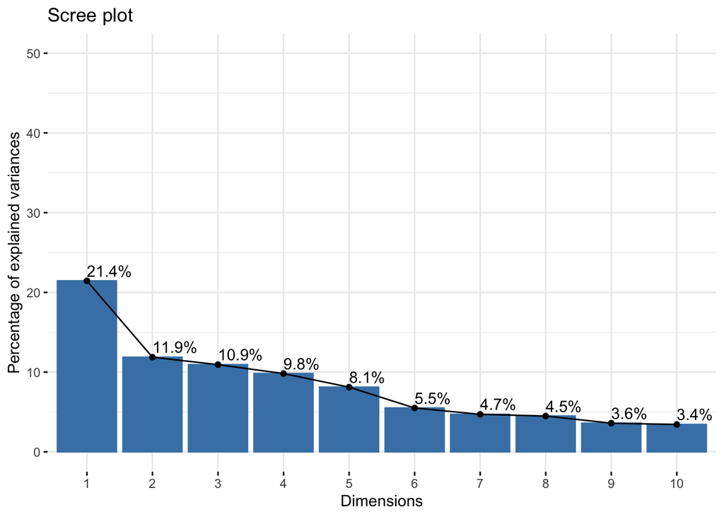

```r
###  Perform PCA with prcomp() ###
# Prepare the dataset
airplane_stype<- airplane_type %>%
  scale %>%
  as.data.frame()

# PCA performed with the function prcomp()
pca_type <- airplane_stype %>%
  prcomp()

# Visualize percentage of variance explained for each PC in a scree plot
fviz_eig(pca_type, addlabels = TRUE, ylim = c(0, 50))
```

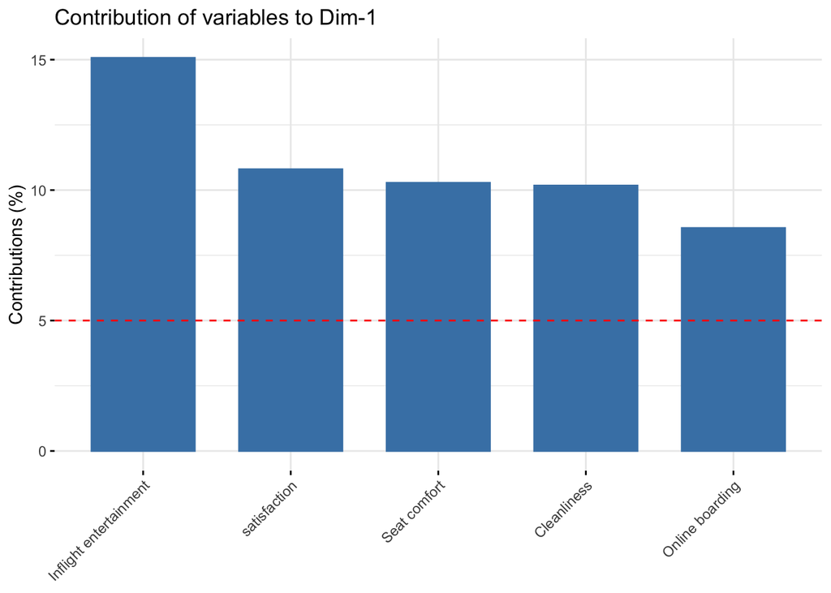

```r
# Visualize according to PC1 and PC2
fviz_contrib(pca_type, choice = "var", axes = 1, top = 5) # on PC1
```

```r
# Perform clustering using kmeans() or pam()
```

[output not shown]

[output not shown]

## 6. Discussion

Answer your research questions, reflect on the process, and include acknowledgements.

## 7. Formatting

Remember to knit your file and produce a pdf with multiple pages to upload on Gradescope. It is ok to not follow the structure of the project in order but make sure to identify the pages accordingly.